# Practical Machine Learning Assignment

Jerome Locson

1/27/2019

## Background

Using devices such as Jawbone Up, Nike FuelBand, and Fitbit it is now possible to collect a large amount of data about personal activity relatively inexpensively. These type of devices are part of the quantified self movement – a group of enthusiasts who take measurements about themselves regularly to improve their health, to find patterns in their behavior, or because they are tech geeks. One thing that people regularly do is quantify how much of a particular activity they do, but they rarely quantify how well they do it. In this project, your goal will be to use data from accelerometers on the belt, forearm, arm, and dumbell of 6 participants. They were asked to perform barbell lifts correctly and incorrectly in 5 different ways. More information is available from the website here: http://web.archive.org/web/20161224072740/http:/groupware.les.inf.puc-rio.br/har (see the section on the Weight Lifting Exercise Dataset).

The data for this project come from this source: http://web.archive.org/web/20161224072740/http:/groupware.les.inf.puc-rio.br/har.

- The training data for this project are available here: https://d396qusza40orc.cloudfront.net/predmachlearn/pml-training.csv
- The test data are available here: https://d396qusza40orc.cloudfront.net/predmachlearn/pml-testing.csv

## Data Exploration and Cleaning

Assuming that we have downloaded the training and test datasets from the sources mentioned above, we will now load and clean the datasets. Please change the CSV file directory accordingly.

```r
# Load the training dataset
training_dataset <- read.csv("data/pml-training.csv", na.strings=c("NA","#DIV/0!",""))
# Load the testing dataset
testing_dataset <- read.csv("data/pml-testing.csv", na.strings=c("NA","#DIV/0!",""))
```

Now, let’s examine the dataset dimensions:

```r
dim(training_dataset)
```

```
## [1] 19622   160
```

```r
dim(testing_dataset)
```

```
## [1]  20 160
```

The training dataset has 19622 rows and 160 columnns. Likewise, the test dataset has 20 rows and 160 columnns. Both seems to have the same number of column, which is good.

Now, we need to clean the datasets, we only need columns that are relavant. We need to remove all columns with 95% N/A values.

```r
na_var_test <- sapply(testing_dataset, function(x) mean(is.na(x))) > 0.95
training_dataset <- training_dataset[ , na_var_test == FALSE]
testing_dataset <- testing_dataset[ , na_var_test == FALSE]
```

We only need the relavant features for the machine learning models that we will be building.

```r
features <- names(testing_dataset[,colSums(is.na(testing_dataset)) == 0])[8:59]

# Only use features used in testing cases.
training_dataset <- training_dataset[,c(features,"classe")]
testing_dataset <- testing_dataset[,c(features,"problem_id")]
```

Let’s check again the new and cleaned datasets.

```r
dim(training_dataset)
```

```
## [1] 19622    53
```

```r
dim(testing_dataset)
```

```
## [1] 20 53
```

Both datasets are now with 53 and 53 columnns. This looks great! So let’s proceed to the next step.

## Data Partitioning for Training

In this section, we will do data partitioning for the training model that we will build.But first, we will load the necessary libraries that we will be using in this exercise.

```r
library(caret)
library(rpart)
library(rpart.plot)
library(RColorBrewer)
library(rattle)
library(randomForest)
```

Initially, we need to set the seed for reproducibility. A common practice is to split the training dataset into two just to run the training and testing models. Mind you that the **testing** partitioned dataset here is not yet the dataset we have above for final testing. This is just to do cross-validation on how the models will perform.

We will split the training dataset into two, **70% for training and 30% for testing**.

```r
set.seed(2019)
trainingPartition <- createDataPartition(training_dataset$classe, p=0.7, list=FALSE)
training <- training_dataset[trainingPartition,]
testing <- training_dataset[-trainingPartition,]
```

Let’s check the dimension of the split of training dataset.

```r
dim(training)
```

```
## [1] 13737    53
```

```r
dim(testing)
```

```
## [1] 5885   53
```

The result looks good. We have 13737 (70%) and 5885 (30%) rows for training and testing datasets, respectively. Now, let’s build our Machine Learning Models.

## Random Forest (RF) Model

Again, let’s set the seed for reproducibility. We will use the **classe** feature as to where we will build the model. **classe** is the column from the training dataset that classifies how well the participants performs the exercise. The physical exercise was done in five different fashions: exactly according to the specification (Class A), throwing the elbows to the front (Class B), lifting the dumbbell only halfway (Class C), lowering the dumbbell only halfway (Class D) and throwing the hips to the front (Class E). Class A corresponds to the specified execution of the exercise, while the other 4 classes correspond to common mistakes.

Read more: http://groupware.les.inf.puc-rio.br/har#ixzz5dmHjujzJ

```r
set.seed(2019)
rf <- randomForest(classe ~ ., data = training)
rf
```

```
##
## Call:
##  randomForest(formula = classe ~ ., data = training)
##                Type of random forest: classification
##                      Number of trees: 500
## No. of variables tried at each split: 7
##
##         OOB estimate of  error rate: 0.42%
## Confusion matrix:
##      A    B    C    D    E class.error
## A 3906    0    0    0    0 0.000000000
## B   11 2641    6    0    0 0.006395786
## C    0   14 2380    2    0 0.006677796
## D    0    0   18 2234    0 0.007992895
## E    0    0    0    7 2518 0.002772277
```

The data above shows that the RF model was built using **ntree=500** with **mtry=7**. We also see that OOB (Out-of-bag) Error is pretty goood at **0.42%**. This means that the model we have predicts at a level of 99.5% accuracy. As this is a very good rate, we do not need to fine-tune the model.

Let’s see RF in a plot.

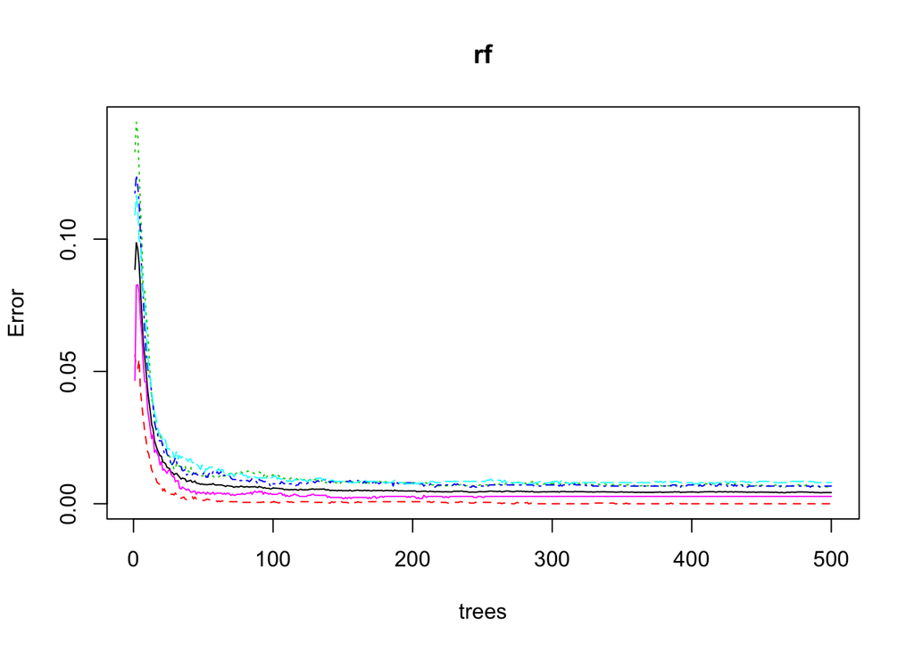

```r
plot(rf)
```

The plot shows that there is no significant error improvements in trees beyond 100. We tried to adjust this with the original RF but the OOB error increase abit. So we will use the default settings instead.

Let’s check the important variables used in the RF model.

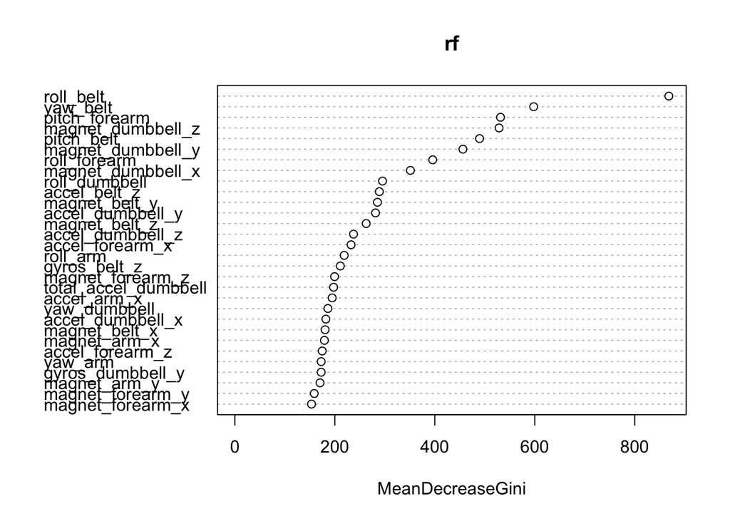

```r
varImpPlot(rf)
```

Okay. So we now have the RF model in place, let’s check and run some predictions using our **training** and **testing** datasets.

```r
predict_rf_1 <- predict(rf, training)
confusionMatrix(predict_rf_1, training$classe)
```

```
## Confusion Matrix and Statistics
##
##           Reference
## Prediction    A    B    C    D    E
##          A 3906    0    0    0    0
##          B    0 2658    0    0    0
##          C    0    0 2396    0    0
##          D    0    0    0 2252    0
##          E    0    0    0    0 2525
##
## Overall Statistics
##
##                Accuracy : 1
##                  95% CI : (0.9997, 1)
##     No Information Rate : 0.2843
##     P-Value [Acc > NIR] : < 2.2e-16
##
##                   Kappa : 1
##  Mcnemar's Test P-Value : NA
##
## Statistics by Class:
##
##                      Class: A Class: B Class: C Class: D Class: E
## Sensitivity            1.0000   1.0000   1.0000   1.0000   1.0000
## Specificity            1.0000   1.0000   1.0000   1.0000   1.0000
## Pos Pred Value         1.0000   1.0000   1.0000   1.0000   1.0000
## Neg Pred Value         1.0000   1.0000   1.0000   1.0000   1.0000
## Prevalence             0.2843   0.1935   0.1744   0.1639   0.1838
## Detection Rate         0.2843   0.1935   0.1744   0.1639   0.1838
## Detection Prevalence   0.2843   0.1935   0.1744   0.1639   0.1838
## Balanced Accuracy      1.0000   1.0000   1.0000   1.0000   1.0000
```

Using the training dataset, we can see that the accuracy is 1 which means it 100% correctly predicted the **classe**.

```r
predict_rf_2 <- predict(rf, testing)
confusionMatrix(predict_rf_2, testing$classe)
```

```
## Confusion Matrix and Statistics
##
##           Reference
## Prediction    A    B    C    D    E
##          A 1674    4    0    0    0
##          B    0 1131    5    0    0
##          C    0    4 1021   16    0
##          D    0    0    0  946    3
##          E    0    0    0    2 1079
##
## Overall Statistics
##
##                Accuracy : 0.9942
##                  95% CI : (0.9919, 0.996)
##     No Information Rate : 0.2845
##     P-Value [Acc > NIR] : < 2.2e-16
##
##                   Kappa : 0.9927
##  Mcnemar's Test P-Value : NA
##
## Statistics by Class:
##
##                      Class: A Class: B Class: C Class: D Class: E
## Sensitivity            1.0000   0.9930   0.9951   0.9813   0.9972
## Specificity            0.9991   0.9989   0.9959   0.9994   0.9996
## Pos Pred Value         0.9976   0.9956   0.9808   0.9968   0.9981
## Neg Pred Value         1.0000   0.9983   0.9990   0.9964   0.9994
## Prevalence             0.2845   0.1935   0.1743   0.1638   0.1839
## Detection Rate         0.2845   0.1922   0.1735   0.1607   0.1833
## Detection Prevalence   0.2851   0.1930   0.1769   0.1613   0.1837
## Balanced Accuracy      0.9995   0.9960   0.9955   0.9904   0.9984
```

Using the testing dataset, we can see that the accuracy is 0.9942 which is very close to 100%.

## Decision Tree (DT) Model

Let’s build another model using Decision Tree. As usual, let’s set seed for reproducibility. using **rpart**, let’s pass the same parameters for our data and use method as **class** for *classification*. A plot shows the built DT model.

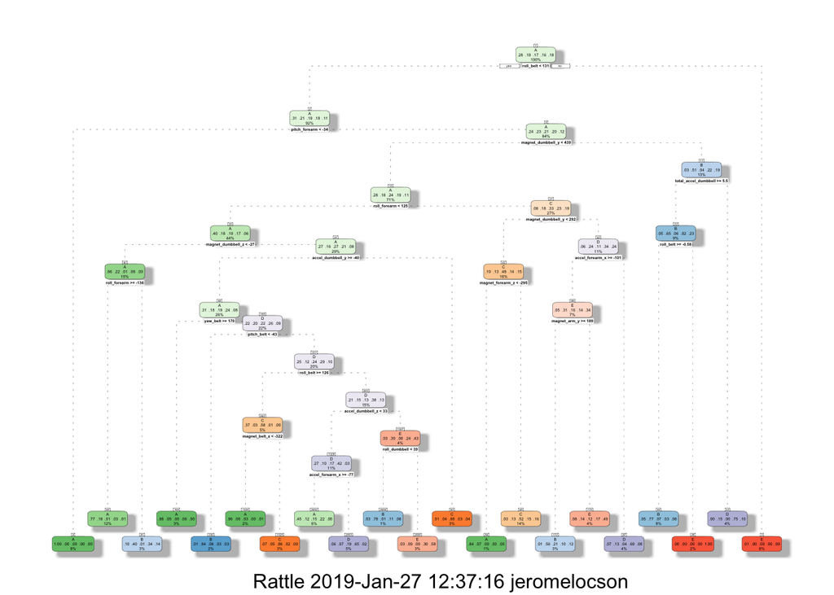

```r
set.seed(2019)
dt <- rpart(classe ~ ., data = training,  method="class")
fancyRpartPlot(dt)
```

Using the DT model, let’s run some predictions using our **training** and **testing** datasets.

```r
predict_dt_1 <- predict(dt, training, type = "class")
confusionMatrix(predict_dt_1, training$classe)
```

```
## Confusion Matrix and Statistics
##
##           Reference
## Prediction    A    B    C    D    E
##          A 3549  447  156  274   63
##          B  107 1595  186  216  207
##          C  105  306 1825  326  326
##          D   84  198  159 1231  106
##          E   61  112   70  205 1823
##
## Overall Statistics
##
##                Accuracy : 0.7296
##                  95% CI : (0.7221, 0.737)
##     No Information Rate : 0.2843
##     P-Value [Acc > NIR] : < 2.2e-16
##
##                   Kappa : 0.6561
##  Mcnemar's Test P-Value : < 2.2e-16
##
## Statistics by Class:
##
##                      Class: A Class: B Class: C Class: D Class: E
## Sensitivity            0.9086   0.6001   0.7617  0.54663   0.7220
## Specificity            0.9044   0.9354   0.9063  0.95237   0.9600
## Pos Pred Value         0.7906   0.6902   0.6319  0.69235   0.8027
## Neg Pred Value         0.9614   0.9070   0.9474  0.91462   0.9388
## Prevalence             0.2843   0.1935   0.1744  0.16394   0.1838
## Detection Rate         0.2584   0.1161   0.1329  0.08961   0.1327
## Detection Prevalence   0.3268   0.1682   0.2102  0.12943   0.1653
## Balanced Accuracy      0.9065   0.7677   0.8340  0.74950   0.8410
```

```r
predict_dt_2 <- predict(dt, testing, type = "class")
confusionMatrix(predict_dt_2, testing$classe)
```

```
## Confusion Matrix and Statistics
##
##           Reference
## Prediction    A    B    C    D    E
##          A 1507  185   70  124   35
##          B   55  671   89   83  102
##          C   51  137  778  144  124
##          D   32   84   72  522   52
##          E   29   62   17   91  769
##
## Overall Statistics
##
##                Accuracy : 0.7217
##                  95% CI : (0.71, 0.7331)
##     No Information Rate : 0.2845
##     P-Value [Acc > NIR] : < 2.2e-16
##
##                   Kappa : 0.646
##  Mcnemar's Test P-Value : < 2.2e-16
##
## Statistics by Class:
##
##                      Class: A Class: B Class: C Class: D Class: E
## Sensitivity            0.9002   0.5891   0.7583   0.5415   0.7107
## Specificity            0.9017   0.9307   0.9062   0.9512   0.9586
## Pos Pred Value         0.7845   0.6710   0.6305   0.6850   0.7944
## Neg Pred Value         0.9579   0.9042   0.9467   0.9137   0.9363
## Prevalence             0.2845   0.1935   0.1743   0.1638   0.1839
## Detection Rate         0.2561   0.1140   0.1322   0.0887   0.1307
## Detection Prevalence   0.3264   0.1699   0.2097   0.1295   0.1645
## Balanced Accuracy      0.9010   0.7599   0.8322   0.7464   0.8346
```

Both resulted to a low Accuracy rate at 0.7296 and 0.7217 compared to the RF model, respectively.

## Prediction with Test Data with 2 Models

Lastly, let’s finally use the RF and DT prediction models to predict 20 different test cases from above.

```r
predictionRF <- predict(rf, testing_dataset)
predictionRF
```

```
##  1  2  3  4  5  6  7  8  9 10 11 12 13 14 15 16 17 18 19 20
##  B  A  B  A  A  E  D  B  A  A  B  C  B  A  E  E  A  B  B  B
## Levels: A B C D E
```

```r
predictionDT <- predict(dt, testing_dataset, type = "class")
predictionDT
```

```
##  1  2  3  4  5  6  7  8  9 10 11 12 13 14 15 16 17 18 19 20
##  C  A  B  D  A  C  D  D  A  A  C  B  C  A  E  E  A  B  B  B
## Levels: A B C D E
```